# STATISTICAL ANALYSIS ON STATLOG HEART DATA SET

### Mathematics in Machine Learning thesis, Emanuele Fasce

This Jupyter Notebook only contains the code used to analyze the dataset in Python and does not focus on theoretical details. The slide presentation provided with this Notebook instead focuses on results and theory, and is better in my opinion to introduce my project. This is the link to it: https://www.canva.com/design/DAD9XE_bnEQ/OvdMWuDYZQX9zJhiaAvPVg/view?utm_content=DAD9XE_bnEQ&utm_campaign=designshare&utm_medium=link&utm_source=publishsharelink

## Summary

#### 1. Preprocessing and exploration

- 1.1 Preprocessing
- 1.2 Dataset exploration
- 1.3 Correlation matrix

#### 2. Dimensionality reduction

- 2.1 PCA

#### 3. Bayesian inference

- 3.1 Bayesian inference

#### 4. Algorithms

- 4.1 Naive Bayes
- 4.2 Decision tree
- 4.3 Random Forest
- 4.4 SVM
- 4.5 Logistic regression

#### 5. Final evaluations

- 5.1 Final evaluations

## 1. Preprocessing and exploration

### 1.1 Preprocessing

The dataset is read.

```python
import pandas as pd
path='heart.dat'
df=pd.read_csv(path)
df['Illness']=df['Illness']-1
illness=df['Illness']
del df['Illness']
df.head()
```

|  | Age | Sex | Chest_Pain_Type | Resting_Blood_Pressure | Serum_Cholesterol | Fasting_Blood_Sugar | Resting_Electrocardiographic_Results | Maximum_Heart_Rate | Exercise_induced_angina | Oldpeak_ST | Slope_ST | Colored_Major_Vessels | Thalassemia |
| --- | --- | --- | --- | --- | --- | --- | --- | --- | --- | --- | --- | --- | --- |
| 0 | 70.0 | 1.0 | 4.0 | 130.0 | 322.0 | 0.0 | 2.0 | 109.0 | 0.0 | 2.4 | 2.0 | 3.0 | 3.0 |
| 1 | 67.0 | 0.0 | 3.0 | 115.0 | 564.0 | 0.0 | 2.0 | 160.0 | 0.0 | 1.6 | 2.0 | 0.0 | 7.0 |
| 2 | 57.0 | 1.0 | 2.0 | 124.0 | 261.0 | 0.0 | 0.0 | 141.0 | 0.0 | 0.3 | 1.0 | 0.0 | 7.0 |
| 3 | 64.0 | 1.0 | 4.0 | 128.0 | 263.0 | 0.0 | 0.0 | 105.0 | 1.0 | 0.2 | 2.0 | 1.0 | 7.0 |
| 4 | 74.0 | 0.0 | 2.0 | 120.0 | 269.0 | 0.0 | 2.0 | 121.0 | 1.0 | 0.2 | 1.0 | 1.0 | 3.0 |

One hot encoding is performed on the dataset. On one dataset one column for each encoded feature is dropped in order to avoid multicollinearity.

```python
df1=pd.get_dummies(df.Resting_Electrocardiographic_Results)
df1.columns=['Resting_Electrocardiographic_Normal', 'Resting_Electrocardiographic_Abnormal', 'Resting_Electrocardiographic_Hypertrophy']
df2=pd.get_dummies(df.Chest_Pain_Type)
df2.columns=['Pain_Typical','Pain_Atypical','Pain_NonAnginal', 'Pain_Asymptomatic']
df3=pd.get_dummies(df.Thalassemia)
df3.columns=['Thalassemia_No', 'Thalassemia_Fixed', 'Thalassemia_Reversable']
df4=pd.get_dummies(df.Slope_ST)
df4.columns=['Slope_Upsloping', 'Slope_Flat', 'Slope_Downsloping']
df_dummy=pd.concat([df,df1,df2,df3, df4], axis=1)

del df_dummy['Slope_ST']
del df_dummy['Chest_Pain_Type']
del df_dummy['Thalassemia']
del df_dummy['Resting_Electrocardiographic_Results']


df_dummy_trap=df_dummy.copy(deep=True)
del df_dummy_trap['Resting_Electrocardiographic_Normal']
del df_dummy_trap['Pain_Typical']
del  df_dummy_trap['Thalassemia_No']
del df_dummy_trap['Slope_Downsloping']

df_dummy_trap.head()
df_dummy_trap['Illness']=illness
df_dummy_trap.to_csv('dummy_trap.csv')
del df_dummy_trap['Illness']

df_dummy.head()
```

|  | Age | Sex | Resting_Blood_Pressure | Serum_Cholesterol | Fasting_Blood_Sugar | Maximum_Heart_Rate | Exercise_induced_angina | Oldpeak_ST | Colored_Major_Vessels | Resting_Electrocardiographic_Normal | ... | Pain_Typical | Pain_Atypical | Pain_NonAnginal | Pain_Asymptomatic | Thalassemia_No | Thalassemia_Fixed | Thalassemia_Reversable | Slope_Upsloping | Slope_Flat | Slope_Downsloping |
| --- | --- | --- | --- | --- | --- | --- | --- | --- | --- | --- | --- | --- | --- | --- | --- | --- | --- | --- | --- | --- | --- |
| 0 | 70.0 | 1.0 | 130.0 | 322.0 | 0.0 | 109.0 | 0.0 | 2.4 | 3.0 | 0 | ... | 0 | 0 | 0 | 1 | 1 | 0 | 0 | 0 | 1 | 0 |
| 1 | 67.0 | 0.0 | 115.0 | 564.0 | 0.0 | 160.0 | 0.0 | 1.6 | 0.0 | 0 | ... | 0 | 0 | 1 | 0 | 0 | 0 | 1 | 0 | 1 | 0 |
| 2 | 57.0 | 1.0 | 124.0 | 261.0 | 0.0 | 141.0 | 0.0 | 0.3 | 0.0 | 1 | ... | 0 | 1 | 0 | 0 | 0 | 0 | 1 | 1 | 0 | 0 |
| 3 | 64.0 | 1.0 | 128.0 | 263.0 | 0.0 | 105.0 | 1.0 | 0.2 | 1.0 | 1 | ... | 0 | 0 | 0 | 1 | 0 | 0 | 1 | 0 | 1 | 0 |
| 4 | 74.0 | 0.0 | 120.0 | 269.0 | 0.0 | 121.0 | 1.0 | 0.2 | 1.0 | 0 | ... | 0 | 1 | 0 | 0 | 1 | 0 | 0 | 1 | 0 | 0 |

5 rows × 22 columns

### 1.2 Dataset exploration

Pie charts for categorical features are visualized.

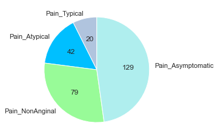

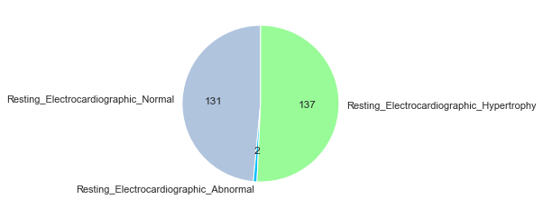

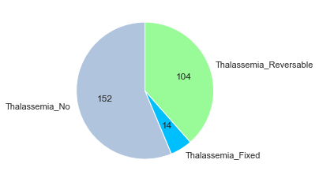

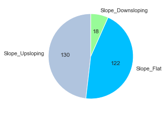

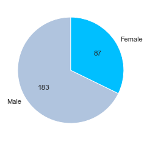

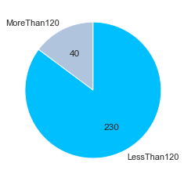

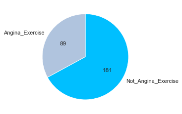

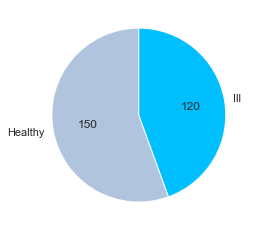

```python
import matplotlib.pyplot as plt

def make_autopct(values):
    def my_autopct(pct):
        total = sum(values)
        val = int(round(pct*total/100.0))
        return '{v:d}'.format(p=pct,v=val)
    return my_autopct

plt.figure()

lab=['Pain_Typical','Pain_Atypical','Pain_NonAnginal', 'Pain_Asymptomatic']
Pain_Typical=len(df2[df2['Pain_Typical']==1])
Pain_Atypical=len(df2[df2['Pain_Atypical']==1])
Pain_NonAnginal=len(df2[df2['Pain_NonAnginal']==1])
Pain_Asymptomatic=len(df2[df2['Pain_Asymptomatic']==1])
sizes=[Pain_Typical,Pain_Atypical,Pain_NonAnginal, Pain_Asymptomatic]
plt.pie(sizes,labels=lab, autopct=make_autopct(sizes), startangle=90, colors=['lightsteelblue', 'deepskyblue', 'palegreen', 'paleturquoise'])

plt.figure()
lab2=['Resting_Electrocardiographic_Normal', 'Resting_Electrocardiographic_Abnormal', 'Resting_Electrocardiographic_Hypertrophy']
Resting_Electrocardiographic_Normal=len(df1[df1['Resting_Electrocardiographic_Normal']==1])
Resting_Electrocardiographic_Abnormal=len(df1[df1['Resting_Electrocardiographic_Abnormal']==1])
Resting_Electrocardiographic_Hypertrophy=len(df1[df1['Resting_Electrocardiographic_Hypertrophy']==1])
sizes=[Resting_Electrocardiographic_Normal, Resting_Electrocardiographic_Abnormal, Resting_Electrocardiographic_Hypertrophy]
plt.pie(sizes,labels=lab2, autopct=make_autopct(sizes), startangle=90, colors=['lightsteelblue', 'deepskyblue', 'palegreen', 'paleturquoise'])

plt.figure()
lab3=['Thalassemia_No', 'Thalassemia_Fixed', 'Thalassemia_Reversable']
Thalassemia_No=len(df3[df3['Thalassemia_No']==1])
Thalassemia_Fixed=len(df3[df3['Thalassemia_Fixed']==1])
Thalassemia_Reversable=len(df3[df3['Thalassemia_Reversable']==1])
sizes=[Thalassemia_No, Thalassemia_Fixed, Thalassemia_Reversable]
plt.pie(sizes,labels=lab3, autopct=make_autopct(sizes), startangle=90, colors=['lightsteelblue', 'deepskyblue', 'palegreen', 'paleturquoise'])

plt.figure()
lab4=['Slope_Upsloping', 'Slope_Flat', 'Slope_Downsloping']
Slope_Upsloping=len(df4[df4['Slope_Upsloping']==1])
Slope_Flat=len(df4[df4['Slope_Flat']==1])
Slope_Downsloping=len(df4[df4['Slope_Downsloping']==1])
sizes=[Slope_Upsloping, Slope_Flat, Slope_Downsloping]
plt.pie(sizes,labels=lab4, autopct=make_autopct(sizes), startangle=90, colors=['lightsteelblue', 'deepskyblue', 'palegreen', 'paleturquoise'])

plt.figure()
lab5=['Male', 'Female']
Male=len(df[df['Sex']==1])
Female=len(df[df['Sex']==0])
sizes=[Male, Female]
plt.pie(sizes,labels=lab5, autopct=make_autopct(sizes), startangle=90, colors=['lightsteelblue', 'deepskyblue', 'palegreen', 'paleturquoise'])

plt.figure()
lab6=['MoreThan120', 'LessThan120']
MoreThan120=len(df[df['Fasting_Blood_Sugar']==1])
LessThan120=len(df[df['Fasting_Blood_Sugar']==0])
sizes=[MoreThan120, LessThan120]
plt.pie(sizes,labels=lab6, autopct=make_autopct(sizes), startangle=90, colors=['lightsteelblue', 'deepskyblue', 'palegreen', 'paleturquoise'])

plt.figure()
lab7=['Angina_Exercise', 'Not_Angina_Exercise']
Angina_Exercise=len(df[df['Exercise_induced_angina']==1])
Not_Angina_Exercise=len(df[df['Exercise_induced_angina']==0])
sizes=[Angina_Exercise, Not_Angina_Exercise]
plt.pie(sizes,labels=lab7, autopct=make_autopct(sizes), startangle=90, colors=['lightsteelblue', 'deepskyblue', 'palegreen', 'paleturquoise'])

plt.figure()
lab8=['Healthy', 'Ill']
Healthy=len(illness[illness==0])
Ill=len(illness[illness==1])
sizes=[Healthy, Ill]
plt.pie(sizes,labels=lab8, autopct=make_autopct(sizes), startangle=90, colors=['lightsteelblue', 'deepskyblue', 'palegreen', 'paleturquoise'])

df_cat=df_dummy[['Pain_Atypical', 'Exercise_induced_angina', 'Fasting_Blood_Sugar', 'Pain_NonAnginal', 'Pain_Asymptomatic', 'Resting_Electrocardiographic_Abnormal', 'Resting_Electrocardiographic_Hypertrophy', 'Thalassemia_Fixed', 'Thalassemia_Reversable', 'Slope_Upsloping', 'Slope_Downsloping', 'Sex']]
```

Boxplots for quantitative features are visualized.

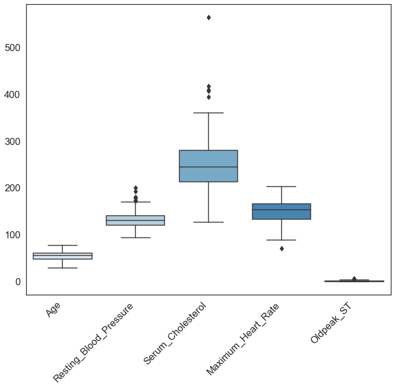

```python
df_real=df[['Age','Resting_Blood_Pressure','Serum_Cholesterol', 'Maximum_Heart_Rate', 'Oldpeak_ST']]
f, ax = plt.subplots(figsize=(11, 9))
sns.set(font_scale=1.2, style='white')
p=sns.boxplot(data = df_real, palette='Blues',fliersize=6)
p.set_xticklabels(p.get_xticklabels())
a=plt.xticks(rotation=45, ha='right')
```

### 1.3 Correlation matrix

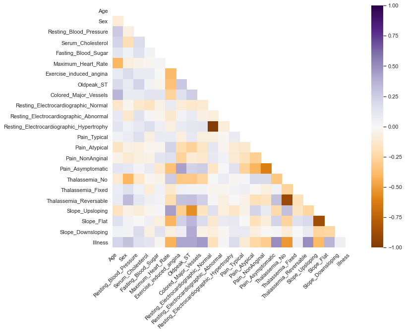

```python
import matplotlib.pyplot as plt
import numpy as np
import seaborn as sns

sns.set(style="white")
%matplotlib inline
df_dummy_trap_corr=df_dummy['Illness']=illness
features=df_dummy.columns.to_list()

mat=df_dummy.corr()
mask = np.triu(np.ones_like(mat, dtype=np.bool))

f, ax = plt.subplots(figsize=(11, 9))
bottom, top = ax.get_ylim()
ax.set_ylim(bottom +1, top -1)
sns.heatmap(mat, cmap='PuOr', vmin=-1, center=0, mask=mask)
a=plt.xticks(rotation=45, ha='right')
```

## 2. Dimensionality reduction

### 2.1 PCA

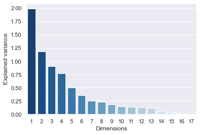

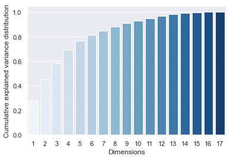

```python
import numpy as np
from sklearn.decomposition import PCA

df_norm_real=(df_real-df_real.mean())/df_real.std()
df_norm=pd.concat([df_norm_real, df_cat], axis=1)

df_real_norm=(df_real-df_real.mean())/df_real.std()

df_real_norm=df_real_norm.join(df_cat)

import plotly
from plotly.offline import plot
import plotly.graph_objs as go

def plot3d(X_reduced, illness):
    trace1 = go.Scatter3d(
        x=X_reduced[:,0],
        y = X_reduced[:,1],
        z = X_reduced[:,2],
        mode='markers',
        marker=dict(
            color=illness,
            colorscale=[(0,"#0085ff"), (1,"#00ffab")],
            size=5,
            opacity=1))

    data = [trace1]
    layout = go.Layout(
        xaxis=dict(
            title='PCA',
            titlefont=dict(
               family='Courier New, monospace',
               size=18,
               color='##00ffab'
           )
       )
    )
    fig = go.Figure(data=data, layout=layout)
    plot(fig, filename='3D PCA')

pca = PCA(n_components=3).fit(df_norm)
X_reduced = pca.transform(df_norm)
trace1 = go.Scatter3d(
    x=X_reduced[:,0],
    y = X_reduced[:,1],
    z = X_reduced[:,2],
    mode='markers',
    marker=dict(
        color=illness,
        colorscale=[(0,"#0085ff"), (1,"#00ffab")],
        size=5,
        opacity=1))

data = [trace1]
layout = go.Layout(
    xaxis=dict(
        title='PCA',
        titlefont=dict(
           family='Courier New, monospace',
           size=18,
           color='#7f7f7f'
       )
   )
)
fig = go.Figure(data=data, layout=layout)
plot(fig, filename='3D PCA.html')

pca_dim=PCA(n_components=17).fit(df_real_norm)
scores = pca_dim.explained_variance_
sns.set(font_scale=1)
x=[i+1 for i in range(len(scores))]
sns.barplot(y=scores, x=x, palette='Blues_r')
plt.xlabel('Dimensions')
plt.ylabel('Explained variance')


scores3=np.cumsum(scores)
scores3_max=max(scores3)
scores3_perc=[]
for s in scores3:
    s=s/scores3_max
    scores3_perc.append(s)

plt.figure()
sns.barplot(y=scores3_perc, x=x, palette='Blues')
b=plt.xlabel('Dimensions')
a=plt.ylabel('Cumulative explained variance distribution')
```

## 3. Bayesian inference

### 3.1 Bayesian inference

The posterior distribution for the mean of the serum cholesterol in ill patients is plotted.

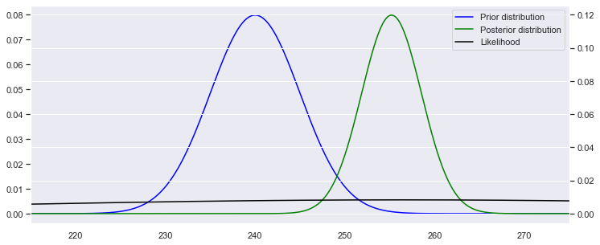

```python
import warnings
import numpy as np
import pandas as pd
import scipy.stats as st
import statsmodels.api as sm
import matplotlib
import matplotlib.pyplot as plt

def make_pdf(dist, params, size=10000):

    arg = params[:-2]
    loc = params[-2]
    scale = params[-1]

    start = dist.ppf(0.00001, *arg, loc=loc, scale=scale) if arg else dist.ppf(0.00001, loc=loc, scale=scale)
    end = dist.ppf(0.99999, *arg, loc=loc, scale=scale) if arg else dist.ppf(0.99999, loc=loc, scale=scale)

    x = np.linspace(215, 275, size)
    y = dist.pdf(x, loc=loc, scale=scale, *arg)
    pdf = pd.Series(y, x)
    return pdf


posterior=make_pdf(dist=st.norm, params=(255.2, 3.33))
data=make_pdf(dist=st.norm, params=(256.46, 48))
prior=make_pdf(dist=st.norm, params=(240, 5))
plt.figure(figsize=(12,5))
ax1 = prior.plot(color='blue', label='Prior distribution')
ax2 = posterior.plot(color='green', secondary_y=True, label='Posterior distribution')
ax3=data.plot(color='black', secondary_y=True, label='Likelihood')
h1, l1 = ax1.get_legend_handles_labels()
h2, l2 = ax2.get_legend_handles_labels()
h3, l3 = ax3.get_legend_handles_labels()

plt.legend(h1+h2+h3, l1+l2, loc=1)
plt.show()
```

Simulation is performed in order to find the posterior distribution of the serum cholesterol in healthy patients.

```python
import pymc3 as pm
import numpy as np

with pm.Model() as model:
    alpha= pm.Uniform('alpha', lower=8, upper=16)
    beta= pm.Uniform('beta', lower=0.01, upper=0.1)
    observed_data = pm.Gamma('observed_data', alpha=alpha, beta=beta, observed=df_healthy['Serum_Cholestoral'].values)
with model:
    trace = pm.sample(draws=80, chains=50, tune=2000,
                      discard_tuned_samples=True)
```

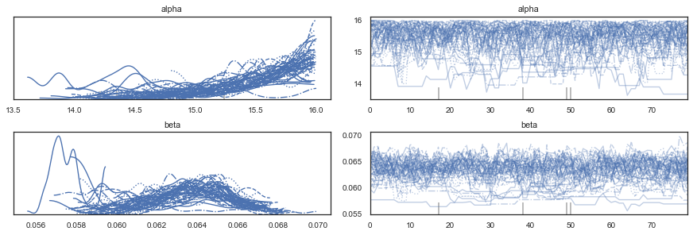

```python
a=pm.traceplot(trace)
```

A gamma distribution with the MAP coefficients alpha and beta is plotted and compared to our initial data.

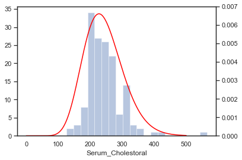

```python
from scipy import stats
import numpy as np
import seaborn as sns

df['Illness']=illness
x=np.linspace(0,500,1500)
y=stats.gamma.pdf(x, a=15.322, scale=1/0.063)
pdf=pd.Series(y, x)
fig = plt.figure()
sns.set_style('white')
ax1 = fig.add_subplot(111)
df_ill=df[df['Illness']==1]
data=df_healthy['Serum_Cholestoral']
sns.distplot(data, kde=False, ax=ax1, label='Data')
ax2 = ax1.twinx()
ax2.set_ylim([0,0.007])
#align_yaxis(ax1, 0, ax2, 0)
sns.lineplot(x,y, ax=ax2, color='red')
del df['Illness']
```

### 3.1 Naive Bayes

In order to use the Naive Bayes algorithm, a particular library is chosen that take into account both the quantitative and categorical features, using multinomial and gaussian distributions as likelihood.

```python
from sklearn.metrics import accuracy_score
from sklearn.metrics import recall_score

df_naive2=df.copy(deep=True)
df_naive2['Slope_ST']=df_naive2['Slope_ST']-1
df_naive2['Chest_Pain_Type']=df_naive2['Chest_Pain_Type']-1
df_naive2.loc[df_naive2['Thalassemia'] == 3, 'Thalassemia'] =0
df_naive2.loc[df_naive2['Thalassemia'] == 6, 'Thalassemia'] =1
df_naive2.loc[df_naive2['Thalassemia'] == 7, 'Thalassemia'] =2
df_naive2.loc[df_naive2['Resting_Electrocardiographic_Results']==2, 'Resting_Electrocardiographic_Results']=1

train_naive, test_naive, ill_train, ill_test=train_test_split(df_naive2, illness, test_size=0.3, random_state=1)

from mixed_naive_bayes import MixedNB as nb
nb=nb(categorical_features=[1,2,5,6,8,10,12])
a=nb.fit(train_naive, ill_train)
pred=nb.predict(test_naive)
naive_acc=accuracy_score(pred, ill_test)
naive_rec=recall_score(pred, ill_test)
print('Accuracy naive:',naive_acc)
print('Recall naive:',naive_rec)
```

```
[2 4 2 2 2 3 3]
Accuracy naive: 0.8271604938271605
Recall naive: 0.8378378378378378
```

```python
from sklearn.base import BaseEstimator, ClassifierMixin
from sklearn.neighbors import KernelDensity
from sklearn.naive_bayes import CategoricalNB
from sklearn.naive_bayes import MultinomialNB
from sklearn.model_selection import StratifiedKFold
from sklearn.model_selection import ParameterGrid

class KDEClassifier(BaseEstimator, ClassifierMixin):
    def __init__(self, bandwidth=1.0, kernel='gaussian'):
        self.bandwidth = bandwidth
        self.kernel = kernel
    def fit(self, X, y):
        self.classes_ = np.sort(np.unique(y))
        training_sets = [X[y == yi] for yi in self.classes_]
        self.models_ = [KernelDensity(bandwidth=self.bandwidth,
                                      kernel=self.kernel).fit(Xi)
                        for Xi in training_sets]
        self.logpriors_ = [np.log(Xi.shape[0] / X.shape[0])
                           for Xi in training_sets]
        return self
    def predict_proba(self, X):
        logprobs = np.array([model.score_samples(X)
                             for model in self.models_]).T
        result = np.exp(logprobs + self.logpriors_)
        return result / result.sum(1, keepdims=True)
    def predict(self, X):
        return self.classes_[np.argmax(self.predict_proba(X), 1)]

train_naive, test_naive, ill_train, ill_test=train_test_split(df_real, illness, test_size=0.3, random_state=1)

train_naive = train_naive.reset_index(drop=True)
test_naive = test_naive.reset_index(drop=True)
ill_train = ill_train.reset_index(drop=True)
ill_test = ill_test.reset_index(drop=True)

acc_kfold=[]
skfold=StratifiedKFold(n_splits=10)

param_grid = {'bandwidth': [0.01, 0.1, 1, 5, 10, 20, 30, 40, 50, 60]}

i=0
for comb in list(ParameterGrid(param_grid)):
    acc_tot=0
    for train_index, test_index in skfold.split(train_naive, ill_train):
        kde=KDEClassifier(kernel='gaussian', bandwidth=comb['bandwidth'])
        kde.fit(train_naive.iloc[train_index], ill_train.iloc[train_index])
        pred=kde.predict(train_naive.iloc[test_index])
        acc_tot+=np.sum(pred==ill_train.iloc[test_index])
    acc_kfold.append(acc_tot/len(train_naive))

winner_kfold=list(ParameterGrid(param_grid))[np.argmax(acc_kfold)]

kde=KDEClassifier(kernel='gaussian', bandwidth=winner_kfold['bandwidth'])
kde.fit(train_naive, ill_train)
pred=kde.predict_proba(test_naive)

train_naive, test_naive, ill_train, ill_test=train_test_split(df_cat, illness, test_size=0.3, random_state=1)

catnb=MultinomialNB()
catnb.fit(train_naive, ill_train)
pred2=catnb.predict_proba(test_naive)
post_ill=81/(81+108)
post_healthy=108/(81+108)

predtot=np.multiply(pred2, pred)
predtot[:,0]=predtot[:,0]/post_healthy
predtot[:,1]=predtot[:,1]/post_ill

predtot_arr=[]
for v in predtot:
    if v[0]>v[1]:
        predtot_arr.append(0)
    else:
        predtot_arr.append(1)

naive_acc_kde=accuracy_score(predtot_arr, ill_test)
naive_rec_kde=recall_score(predtot_arr, ill_test)
print('Accuracy naive kde: ',naive_acc_kde)
print('Recall naive kde:',naive_rec_kde)
```

```
Accuracy naive kde:  0.8024691358024691
Recall naive kde: 0.8285714285714286
```

Here the approximation with the KDE method for different values of the bandwidth is shown.

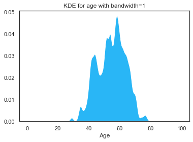

[figure not shown]

```python
X_plot = np.linspace(0, 100, 1000)[:, np.newaxis]
kde = KernelDensity(kernel='gaussian', bandwidth=1).fit(df['Age'].to_numpy().reshape(-1, 1))
log_dens = kde.score_samples(X_plot)
f, ax = plt.subplots(1)
plt.fill(X_plot[:, 0], np.exp(log_dens), fc='#29B6F6')
plt.title('KDE for age with bandwidth=1')
plt.xlabel('Age')
ax.set_ylim(ymin=0)

kde = KernelDensity(kernel='gaussian', bandwidth=5).fit(df['Age'].to_numpy().reshape(-1, 1))
log_dens = kde.score_samples(X_plot)
f, ax = plt.subplots(1)
plt.fill(X_plot[:, 0], np.exp(log_dens), fc='#29B6F6')
plt.title('KDE for age with bandwidth=20')
plt.xlabel('Age')
a=ax.set_ylim(ymin=0)
```

### 3.2 Decision tree

Here a default decision tree is built without any validation technique and using default parameters. It is then visualized.

```
Accuracy simple tree: 0.7283950617283951
```

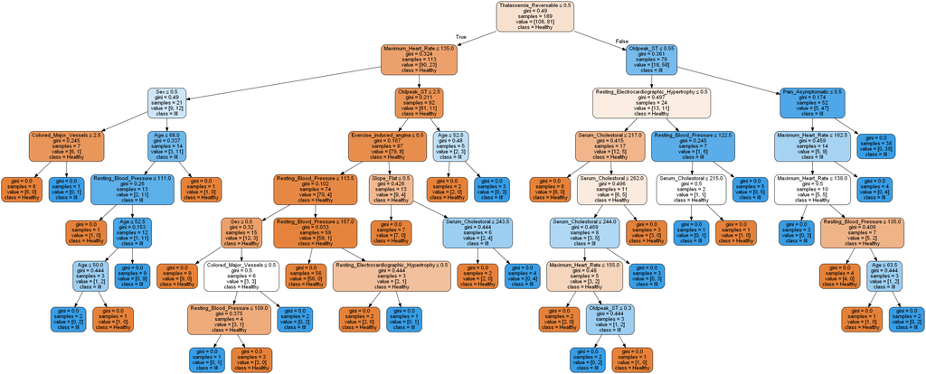

```python
from sklearn import model_selection as m
from sklearn import tree
from sklearn.metrics import accuracy_score, recall_score
import matplotlib.pyplot as plt

%matplotlib inline

train, test, illness_train, illness_test=m.train_test_split(df_dummy_trap, illness, test_size=0.3, random_state=1)
decision=tree.DecisionTreeClassifier()
decision.fit(train, illness_train)
pred=decision.predict(test)

decision_acc=accuracy_score(pred,illness_test)
decision_rec=recall_score(pred, illness_test)

from sklearn import metrics as metr
acc=metr.accuracy_score(illness_test, pred)
dec=decision.decision_path(train)

from sklearn.externals.six import StringIO
from IPython.display import Image
from sklearn.tree import export_graphviz
import pydotplus
import os

os.environ['PATH'] = os.environ['PATH']+';'+os.environ['CONDA_PREFIX']+r"\Library\bin\graphviz"
dot_data = StringIO()
export_graphviz(decision, out_file=dot_data,feature_names=df_dummy_trap.columns, class_names=['Healthy', 'Ill'],
                filled=True, rounded=True,
                special_characters=True)
graph = pydotplus.graph_from_dot_data(dot_data.getvalue())
print('Accuracy simple tree:', acc)
Image(graph.create_png())
```

Two trees are now built using two different cross validation methods, Leave One Out CV and K-Fold CV.

A grid-search is performed to select the best parameters among:

'Criterion': 'gini', entropy

'max_features': auto, sqrt, log2

'splitter': best, random

'max_depth': 3,4,5,6,7, None

```python
from sklearn.metrics import recall_score
from sklearn.model_selection import LeaveOneOut
import numpy as np
from sklearn import tree
import matplotlib.pyplot as plt
from sklearn import model_selection as m
from sklearn.model_selection import ParameterGrid
from sklearn.metrics import accuracy_score

train, test, illness_train, illness_test=m.train_test_split(df_dummy_trap, illness, test_size=0.3, random_state=1)

loocv=LeaveOneOut()
param_grid = {'criterion': ['gini', 'entropy'], 'max_features': ['auto', 'sqrt', 'log2'], 'splitter':['best', 'random'],
              'max_depth':[3,4,5,6,7, None]}

acc_loo=[]
i=0
for comb in list(ParameterGrid(param_grid)):
    acc_total=0
    for train_index, test_index in loocv.split(train, illness_train):
        X_train, X_test = df_dummy.loc[train_index], df_dummy.loc[test_index]
        y_train, y_test=illness[train_index], illness[test_index]
        decision=tree.DecisionTreeClassifier(criterion=comb['criterion'], max_depth=comb['max_depth'], max_features=comb['max_features'], splitter=comb['splitter'])
        decision.fit(X_train, y_train)
        pred=decision.predict(X_test)
        acc=accuracy_score(pred, y_test)
        acc_total+=acc
    acc_loo.append(acc_total/len(df_dummy))
    i=i+1

from sklearn.model_selection import StratifiedKFold

acc_kfold=[]
skfold=StratifiedKFold(n_splits=10)

i=0
for comb in list(ParameterGrid(param_grid)):
    acc_total=0
    for train_index, test_index in skfold.split(train, illness_train):
        X_train, X_test = df_dummy.loc[train_index], df_dummy.loc[test_index]
        y_train, y_test=illness[train_index], illness[test_index]
        decision=tree.DecisionTreeClassifier(criterion=comb['criterion'], max_depth=comb['max_depth'], max_features=comb['max_features'], splitter=comb['splitter'])
        decision.fit(X_train, y_train)
        pred=decision.predict(X_test)
        acc_total+=np.sum(pred==y_test)
    acc_kfold.append(acc_total/len(df_dummy))
    i=i+1


winner_loo=list(ParameterGrid(param_grid))[np.argmax(acc_loo)]
winner_kfold=list(ParameterGrid(param_grid))[np.argmax(acc_kfold)]

decision=tree.DecisionTreeClassifier(criterion=winner_loo['criterion'], max_depth=winner_loo['max_depth'], max_features=winner_loo['max_features'], splitter=winner_loo['splitter'])
decision.fit(train, illness_train)
pred=decision.predict(test)
decision_loo_acc=accuracy_score(pred,illness_test)
decision_loo_rec=recall_score(pred, illness_test)
print("Accuracy LOOCV tree:",accuracy_score(pred,illness_test))
print("Recall LOOCV tree:",recall_score(pred, illness_test))


decision=tree.DecisionTreeClassifier(criterion=winner_kfold['criterion'], max_depth=winner_kfold['max_depth'], max_features=winner_kfold['max_features'], splitter=winner_kfold['splitter'])
decision.fit(train, illness_train)
pred=decision.predict(test)
decision_kfold_acc=accuracy_score(pred,illness_test)
decision_kfold_rec=recall_score(pred, illness_test)
print("Accuracy KFold tree:",accuracy_score(pred,illness_test))
print("Recall KFold tree:",recall_score(pred, illness_test))
```

```
Accuracy LOOCV tree: 0.6790123456790124
Recall LOOCV tree: 0.696969696969697
Accuracy KFold tree: 0.7901234567901234
Recall KFold tree: 0.775
```

### 3.3 Random forest

The accuracy with respect to the number of trees is shown and the importance of the features is plotted.

```
Accuracy random forest: 0.8395061728395061
Recall random forest: 0.8823529411764706
```

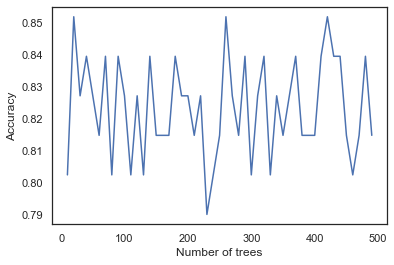

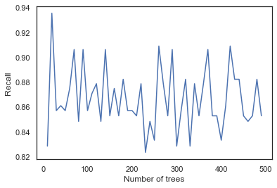

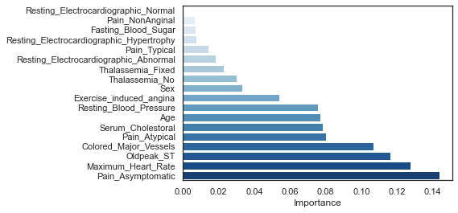

```python
from sklearn.ensemble import RandomForestClassifier
estimators=[i for i in range(500) if i%10==0 and i!=0]
acc_random=[]
rec_random=[]
for e in estimators:
    rfc=RandomForestClassifier(n_estimators=e)
    rfc.fit(train, illness_train)
    pred=rfc.predict(test)
    acc=accuracy_score(pred,illness_test)
    rec=recall_score(pred,illness_test)
    acc_random.append(acc)
    rec_random.append(rec)
plt.plot(estimators, acc_random)
plt.xlabel('Number of trees')
plt.ylabel('Accuracy')
plt.figure()
plt.plot(estimators, rec_random)
plt.xlabel('Number of trees')
plt.ylabel('Recall')

rfc=RandomForestClassifier(n_estimators=80)
rfc.fit(train, illness_train)
pred=rfc.predict(test)
forest_acc=accuracy_score(pred,illness_test)
forest_rec=recall_score(pred,illness_test)
print('Accuracy random forest:',forest_acc)
print('Recall random forest:',forest_rec)

import seaborn as sns
cols=df_dummy.columns
imp=rfc.feature_importances_
imp_index = imp.argsort()
imp_sort = imp[imp_index]
cols_sort=cols[imp_index]
plt.figure()
sns.barplot(x=imp_sort ,y=cols_sort, palette='Blues')
a=plt.xlabel('Importance')
```

### 3.4 SVM

The standard SVM of the Scikit library (implemented through a quadratic programming approach) is performed with a grid-search on the different values of C.

```python
import numpy as np
from sklearn.model_selection import ParameterGrid
from sklearn.metrics import accuracy_score
from sklearn.svm import SVC
from sklearn.model_selection import StratifiedKFold
from sklearn.decomposition import PCA
from sklearn.metrics import recall_score

train, test, illness_train, illness_test, train_c, test_c=m.train_test_split(df_real, illness, df_cat, test_size=0.3, random_state=1)

train_s=(train-train.mean())/train.std()
test_s=(test-test.mean())/test.std()

train_s=train_s.join(train_c)
test_s=test_s.join(test_c)

train_s=train_s.reset_index(drop=True)
test_s=test_s.reset_index(drop=True)
illness_train=illness_train.reset_index(drop=True)
illness_test=illness_test.reset_index(drop=True)

param_grid = {'C': [0.001,0.01,0.1,1,10,100,1000]}
skfold=StratifiedKFold(n_splits=5)

acc_svc=[]
for comb in list(ParameterGrid(param_grid)):
    acc_total=0
    for train_index, test_index in skfold.split(train_s, illness_train):
        X_train, X_test = train_s.loc[train_index], train_s.loc[test_index]
        y_train, y_test=illness_train[train_index], illness_train[test_index]
        svc=SVC(kernel='linear', C=comb['C'])
        svc.fit(X_train, y_train)
        pred=svc.predict(X_test)
        acc_total+=np.sum(pred==y_test)
    acc_svc.append(acc_total/len(train))

winner_svc=list(ParameterGrid(param_grid))[np.argmax(acc_svc)]
svc=SVC(kernel='linear', C=winner_svc['C'])
svc.fit(train_s, illness_train)
pred=svc.predict(test_s)
pca=PCA(n_components=3)
train_pca=pca.fit_transform(train_s)
train_pca_norm=(train_pca-train_pca.mean())/train_pca.std()
pred_linear=svc.predict(test_s)
linearsvm_acc=accuracy_score(pred_linear, illness_test)
linearsvm_rec=recall_score(pred,illness_test)
print('Accuracy linear SVM with C=', winner_svc['C'], ':', linearsvm_acc)
print('Recall linear SVM with C=', winner_svc['C'], ': ', linearsvm_rec)

from sklearn.svm import SVC

param_grid = {'C': [0.001,0.01,0.1,1,10,100,1000]}
acc_svc_rbf=[]
i=0
for comb in list(ParameterGrid(param_grid)):
    acc_total=0
    for train_index, test_index in skfold.split(train_s, illness_train):
        X_train, X_test = train_s.loc[train_index], train_s.loc[test_index]
        y_train, y_test=illness_train[train_index], illness_train[test_index]
        svc=SVC(kernel='linear', C=comb['C'])
        svc.fit(X_train.values, y_train)
        pred=svc.predict(X_test.values)
        acc_total+=np.sum(pred==y_test)
    acc_svc_rbf.append(acc_total/len(train_s))

winner_svc_rbf=list(ParameterGrid(param_grid))[np.argmax(acc_svc_rbf)]
svc=SVC(kernel='rbf', C=winner_svc_rbf['C'])
svc.fit(train_s, illness_train)
pred=svc.predict(test_s)

rbfsvm_acc=accuracy_score(pred, illness_test)
rbfsvm_rec=recall_score(pred, illness_test)

print('Accuracy rbf kernel SVM with C=', winner_svc_rbf['C'], ':', rbfsvm_acc)
print('Recall rbf kernel SVM with C=', winner_svc_rbf['C'], ': ', rbfsvm_rec)
```

```
Accuracy linear SVM with C= 0.1 : 0.8271604938271605
Recall linear SVM with C= 0.1 :  0.8787878787878788
Accuracy rbf kernel SVM with C= 0.1 : 0.7283950617283951
Recall rbf kernel SVM with C= 0.1 :  0.9047619047619048
```

### 3.5 Logistic Regression

```python
from sklearn.linear_model import LogisticRegression

train, test, illness_train, illness_test=m.train_test_split(df_dummy_trap, illness, test_size=0.3, random_state=1)
lr=LogisticRegression(solver='liblinear')
lr.fit(train, illness_train)
pred=lr.predict(test)
lr_acc=accuracy_score(pred, illness_test)
lr_rec=recall_score(pred, illness_test)

print('Logistic regression accuracy:', lr_acc)
print('Logistic regression recall:', lr_rec)

df_dummy_small=df_dummy_trap[['Sex', 'Maximum_Heart_Rate', 'Colored_Major_Vessels', 'Pain_Asymptomatic', 'Thalassemia_Reversable', 'Exercise_induced_angina', 'Oldpeak_ST']]
train, test, illness_train, illness_test=m.train_test_split(df_dummy_small, illness, test_size=0.3, random_state=1)
lr=LogisticRegression(solver='liblinear')
lr.fit(train, illness_train)
pred=lr.predict(test)
lr_acc_small=accuracy_score(pred, illness_test)
lr_rec_small=recall_score(pred, illness_test)

print('Logistic regression accuracy:', lr_acc_small)
print('Logistic regression recall:', lr_rec_small)
```

```
Logistic regression accuracy: 0.8518518518518519
Logistic regression recall: 0.9090909090909091
Logistic regression accuracy: 0.8395061728395061
Logistic regression recall: 0.9333333333333333
```

## 4 Results Evaluation

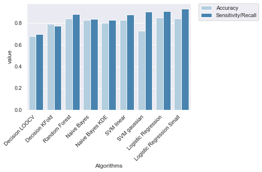

```python
your_df=pd.DataFrame(data={'Algorithms': ['Decision LOOCV','Decision KFold','Random Forest', 'Naive Bayes', 'Naive Bayes KDE', 'SVM linear', 'SVM gaussian', 'Logistic Regression', 'Logistic Regression Small'],
      'Accuracy':[decision_loo_acc, decision_kfold_acc, forest_acc, naive_acc, naive_acc_kde, linearsvm_acc, rbfsvm_acc, lr_acc, lr_acc_small],
      'Sensitivity/Recall' : [decision_loo_rec, decision_kfold_rec, forest_rec, naive_rec, naive_rec_kde, linearsvm_rec, rbfsvm_rec, lr_rec, lr_rec_small]})

long_df = pd.melt(your_df,id_vars = ['Algorithms'],value_vars =['Accuracy','Sensitivity/Recall'])

my_plot = sns.barplot(x="Algorithms",y='value',hue = "variable", data=long_df, palette='Blues')
plt.legend(bbox_to_anchor=(1.05, 1), loc=2, borderaxespad=0.)
a=plt.xticks(rotation=45, ha='right')
```